# Practical Machine Learning - Prediction Assignment Writeup

## by: John Bohorquez

# Summary

One thing that people regularly do is quantify how much of a particular activity they do, but they rarely quantify how well they do it. In this project, our goal will be to use data from accelerometers on the belt, forearm, arm, and dumbell of 6 participants. The purpose of this project is to predict the manner in which they did the exercise.

## Background

Using devices such as Jawbone Up, Nike FuelBand, and Fitbit it is now possible to collect a large amount of data about personal activity relatively inexpensively. These type of devices are part of the quantified self movement – a group of enthusiasts who take measurements about themselves regularly to improve their health, to find patterns in their behavior, or because they are tech geeks. One thing that people regularly do is quantify how much of a particular activity they do, but they rarely quantify how well they do it. In this project, your goal will be to use data from accelerometers on the belt, forearm, arm, and dumbell of 6 participants. They were asked to perform barbell lifts correctly and incorrectly in 5 different ways.

### 1: Load the data

The information is available from the website http://web.archive.org/web/20161224072740/http:/groupware.les.inf.puc-rio.br/har. Section Weight Lifting Exercise Dataset.

Datasets

The training data for this project are available here: https://d396qusza40orc.cloudfront.net/predmachlearn/pml-training.csv

The test data are available here: https://d396qusza40orc.cloudfront.net/predmachlearn/pml-testing.csv

Loading data

```r
train_website <- "http://d396qusza40orc.cloudfront.net/predmachlearn/pml-training.csv"
download.file(train_website, destfile = "./train.csv")
train_data <- read.table("./train.csv", sep =",", header = T)
test_website <- "http://d396qusza40orc.cloudfront.net/predmachlearn/pml-testing.csv"
download.file(test_website, destfile = "./test.csv")
test_data <- read.table("./test.csv", sep =",", header = T)
```

### 2: Explore and clean the data

Perform a general overview of the datasets.

```r
## Check basic information to determine the dataset size.
library(caret)
dim(train_data)
dim(test_data)
colnames(train_data)
head(train_data[1:6, 1:10])
##  Clean the datasets with nearZeroVar to excluded worthlerss variables.
zero_var <- nearZeroVar(train_data)
train_data1 <- train_data[, -zero_var]
test_data1 <- test_data[, -zero_var]
dim(train_data1)
## Clean the datasets by excluding NA Columns (Threshold 80%).
na_column <- sapply(train_data1, function(x) mean(is.na(x))) > 0.8
train_data2 <- train_data1[, na_column == FALSE]
test_data2 <- test_data1[, na_column == FALSE]
dim(train_data2)
## Removing labeled columns that are not part of the records.
train_data3 <- train_data2[, 7:59]
test_data3 <- test_data2[, 7:59]
dim(train_data3)
```

### 3: Data Subseting (Training & testing)

Set a training partition in about 60% and 40% for testing purposes.

```r
train_split <- createDataPartition(train_data3$classe, p=0.6, list=FALSE)
train_sample <- train_data3[train_split,]
test_sample <- train_data3[-train_split,]
dim(train_sample)
dim(test_sample)
```

### 4: Prediction Models

Analyze different models to see which one has the higher accuracy

#### 4.1: Random Forest

All Variables

```r
## This option contains all the variables
modelrfcv <- train(classe ~ ., data=train_sample, ntree=100, method='rf', trControl=trainControl(method="cv", number=5))
```

```r
set.seed(12345)
rfcv_predict <- predict(modelrfcv, test_sample)
rfcv_predict_conf <- confusionMatrix(rfcv_predict, test_sample$classe)
```

PCA preProcessing

```r
## PCA method might shrink the predictors
modelrfcvpca <- train(classe ~ ., data=train_sample, ntree=100, method='rf', preProcess="pca", trControl=trainControl(method="cv", number=5))
modelrfcvpca$finalModel
```

```
##
## Call:
##  randomForest(x = x, y = y, ntree = 100, mtry = param$mtry)
##                Type of random forest: classification
##                      Number of trees: 100
## No. of variables tried at each split: 2
##
##         OOB estimate of  error rate: 3.68%
## Confusion matrix:
##      A    B    C    D    E class.error
## A 3291   26   14   12    5  0.01702509
## B   52 2159   50    2   16  0.05265467
## C   13   41 1966   24   10  0.04284323
## D    7    3   87 1829    4  0.05233161
## E    4   17   25   21 2098  0.03094688
```

```r
set.seed(12345)
rfcvpca_predict <- predict(modelrfcvpca, test_sample)
rfcvpca_predict_conf <- confusionMatrix(rfcvpca_predict, test_sample$classe)
```

#### 4.2: Decision Tree

Les’t run this model with prediction portion

```r
library(rattle)
```

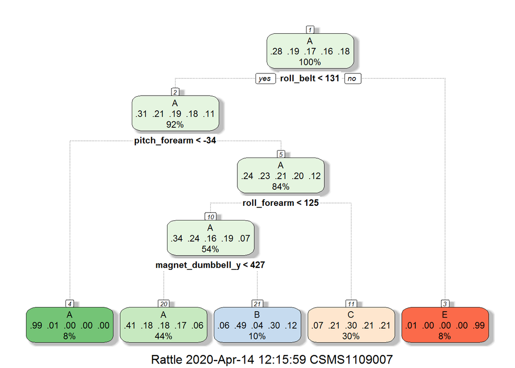

```r
modeldt <- train(classe ~. , data=train_sample, method= "rpart")
fancyRpartPlot(modeldt$finalModel)
```

```r
set.seed(12345)
dt_predict <- predict(modeldt, test_sample)
dt_predict_conf <- confusionMatrix(dt_predict, test_sample$classe)
```

#### 4.3: Boosting (GBM)

Last model to do a comparison with early options

```r
library(gbm)
set.seed(12345)
modelgbm <- train(classe~., data=train_sample, method="gbm", verbose= FALSE)
```

```r
gbm_predict <- predict(modelgbm, test_sample)
gbm_predict_conf <- confusionMatrix(gbm_predict, test_sample$classe)
```

##### Comparison to select the fittest model

```r
rfcv_predict_conf$overall
```

```
##       Accuracy          Kappa  AccuracyLower  AccuracyUpper   AccuracyNull
##      0.9922253      0.9901647      0.9900242      0.9940479      0.2844762
## AccuracyPValue  McnemarPValue
##      0.0000000            NaN
```

```r
rfcvpca_predict_conf$overall
```

```
##       Accuracy          Kappa  AccuracyLower  AccuracyUpper   AccuracyNull
##   9.674994e-01   9.588846e-01   9.633342e-01   9.713123e-01   2.844762e-01
## AccuracyPValue  McnemarPValue
##   0.000000e+00   8.185305e-08
```

```r
dt_predict_conf$overall
```

```
##       Accuracy          Kappa  AccuracyLower  AccuracyUpper   AccuracyNull
##   4.849605e-01   3.280112e-01   4.738456e-01   4.960866e-01   2.844762e-01
## AccuracyPValue  McnemarPValue
##  5.165508e-307            NaN
```

```r
gbm_predict_conf$overall
```

```
##       Accuracy          Kappa  AccuracyLower  AccuracyUpper   AccuracyNull
##   0.9652052001   0.9559736736   0.9609098378   0.9691503147   0.2844761662
## AccuracyPValue  McnemarPValue
##   0.0000000000   0.0003266258
```

### 5: Conclusion

Based on the statistics the best model for our project is Random Forest (Without PCA preProcessing), since the accurracy is higher than other options.

##### Cross Validation

This tool is useful with procesess or databases that do not have a wide variation along the time, as we saw in the Forecast slides. For personal purposes, I’m interested to evaluate seasonal behaviors to enhance the prediction process in my field.

```r
rfcv_predict_conf
```

```
## Confusion Matrix and Statistics
##
##           Reference
## Prediction    A    B    C    D    E
##          A 2229   10    0    1    0
##          B    2 1501    5    0    0
##          C    1    6 1355   18    1
##          D    0    1    8 1260    1
##          E    0    0    0    7 1440
##
## Overall Statistics
##
##                Accuracy : 0.9922
##                  95% CI : (0.99, 0.994)
##     No Information Rate : 0.2845
##     P-Value [Acc > NIR] : < 2.2e-16
##
##                   Kappa : 0.9902
##
##  Mcnemar's Test P-Value : NA
##
## Statistics by Class:
##
##                      Class: A Class: B Class: C Class: D Class: E
## Sensitivity            0.9987   0.9888   0.9905   0.9798   0.9986
## Specificity            0.9980   0.9989   0.9960   0.9985   0.9989
## Pos Pred Value         0.9951   0.9954   0.9812   0.9921   0.9952
## Neg Pred Value         0.9995   0.9973   0.9980   0.9960   0.9997
## Prevalence             0.2845   0.1935   0.1744   0.1639   0.1838
## Detection Rate         0.2841   0.1913   0.1727   0.1606   0.1835
## Detection Prevalence   0.2855   0.1922   0.1760   0.1619   0.1844
## Balanced Accuracy      0.9983   0.9938   0.9932   0.9891   0.9988
```

### 6: Prediction

Once selected the best model, is the time to apply it to the original test dataset.

```r
actual_predict <- predict(modelrfcv, test_data3)
actual_predict
```

```
##  [1] B A B A A E D B A A B C B A E E A B B B
## Levels: A B C D E
```